# AI Sovereignty Around the World

POLISCI 158 · AI & Politics · Session 16 · Monday, November 16, 2026

Simone Paci

## Roadmap

1. Part I: Who wins, who depends?
   - AI as a global distributive shock -> who gains
   - Place a country on the dependency stack
2. Part II: What would sovereignty take?
   - Four tests: compute · models · jurisdiction · performance
   - What a “sovereign AI” deal buys, at what cost
3. Part III: How do AI rules travel?
   - Diffusion channels: coercion, competition, learning, emulation · Brussels effect · stack exports
   - State capacity limits what rules deliver

## Last week two powers. This week everyone else?

| US leads | China leads |
| --- | --- |
| compute · chips · money · frontier models | open models · robots · power |

What about the other countries?

Session 14 scoreboard

## Will AI widen or narrow the gap between rich and poor countries?

Widen

Narrow

No change

Not sure

Show of hands · we vote again at the end

# Part I: Who wins and who loses from AI, worldwide?

Most countries will use AI. Few will make it.

## Who is most exposed?

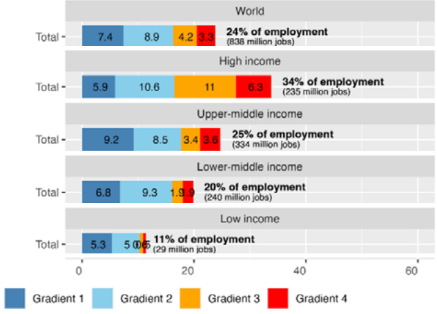

ILO (2025), WP 140, Fig. 20 · CC BY 4.0

Jobs exposed to GenAI, by country income group: high 34% · upper-middle 25% · lower-middle 20% · low 11%

Exposure ≠ gain: “Infrastructure constraints (electricity, broadband), insufficient digital skills, the cost of technology”

Exposure = AI overlaps job tasks, “not the actual impact on employment”

ILO Working Paper 140, Gmyrek et al., May 2025 (Fig. 20)

## Why call AI a distributive shock?

Access -> productivity gains · no access -> falls further behind

“a potential widening of the digital divide and global income disparity”

An IMF projection from 2024, not a measured outcome

Cazzaniga et al., IMF Staff Discussion Note SDN/2024/001, Jan 2024

## Who is actually using it?

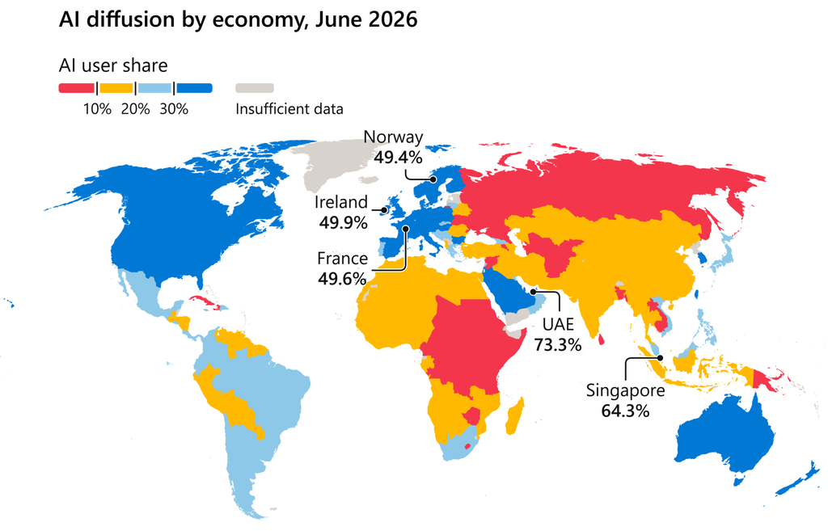

Share of working-age people using GenAI, Q2 2026: Microsoft’s “Global North” 28.8% vs “Global South” 16.2%

- Gap: 9.8 pp (H1 2025) -> 12.6 pp (Q2 2026)
- Top: UAE 73.3% · Singapore 64.3% · US 21st (33.0%)

Vendor telemetry · North/South grouping not defined by Microsoft · use ≠ gain

Microsoft AI Economy Institute, Jan 8 and Sep 21, 2026

## What sits under every AI answer?

## Where are the data centers?

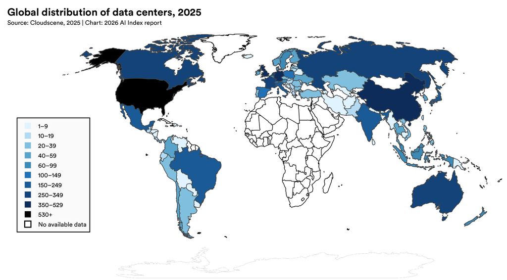

US: 5,427 data centers, more than 10× any other country (2025)

- Germany 529 · UK 523 · China 449 · Brazil 197 · India 153

All data centers, not AI only · count ≠ capacity · white = no data, not zero

Stanford HAI, AI Index 2026, ch. 1 (Cloudscene data)

## Who has state-backed AI supercomputers?

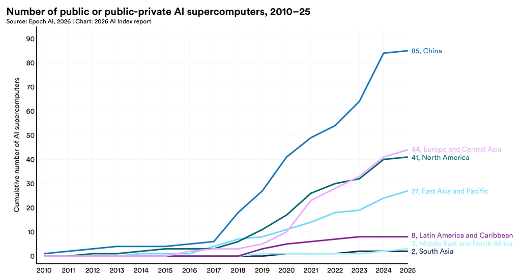

Public or public-private AI supercomputers, 2025: China 85 · Europe & Central Asia 44 · North America 41 · East Asia & Pacific 27 · Latin America & Caribbean 8 · Middle East & North Africa 3 · South Asia 2

Proxy for frontier training capacity · planned systems excluded · no sub-Saharan Africa line

Stanford HAI, AI Index 2026, ch. 8, Fig. 8.3.1 (Epoch AI data)

## Where can you rent AI compute?

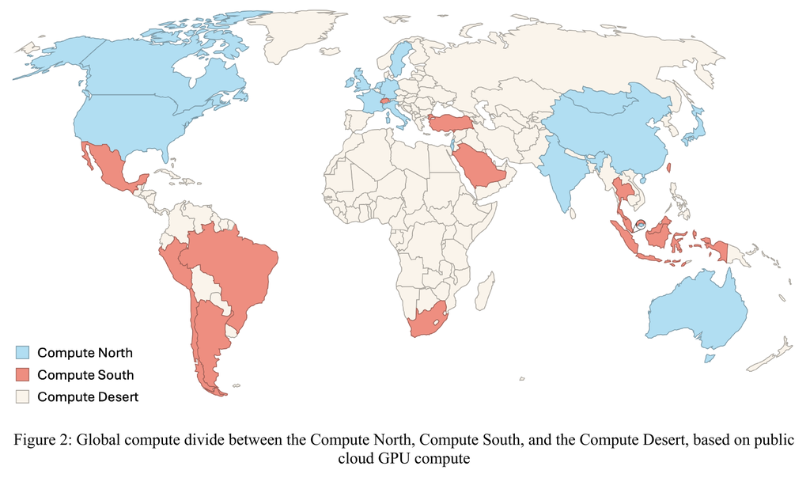

Figure design: Juuso Koponen

39 countries host any public cloud region; 30 with GPUs

- Compute North: US, China + 15 others (all Global North but India)
- Compute South: 13 countries, deployment-grade chips
- Everyone else: “Compute Desert”

As of early 2024 · public cloud only, six hyperscalers

Lehdonvirta, Wu & Hawkins, AIES 2024

## And the chips?

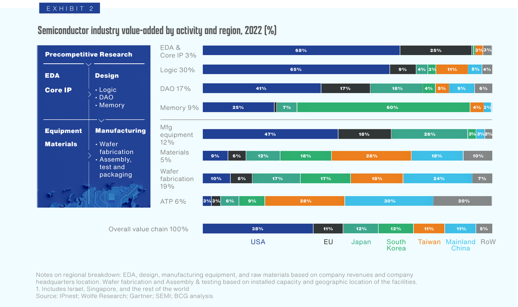

Same chokepoint as Session 14

- “TSMC is a single point of dependency in the global AI supply chain”

Value added by region, 2022

SIA & BCG, May 2024; Stanford HAI, AI Index 2026, ch. 1

## Where do notable models come from?

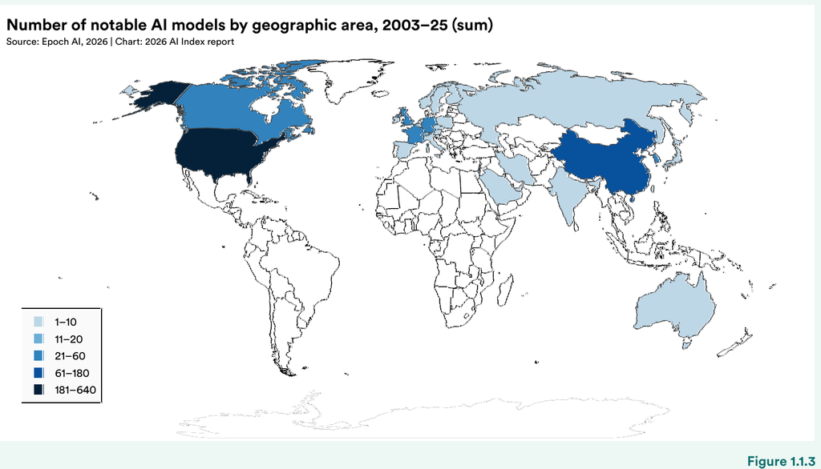

2025: US 59 · China 35 · South Korea 8

2003–25: no notable model on Epoch’s list from Latin America or Africa

Counted by author affiliation · curated list, not a census

Stanford HAI, AI Index 2026, ch. 1 (Epoch AI data)

## Which layer can a country realistically own?

Most countries: buyers, not builders

Chips, cloud compute, frontier models -> concentrated in a few places

Slides 10–14

# Part II: What would it take for a country to rule its own AI?

Every government now says “sovereign”. Few mean the same thing.

## What is AI sovereignty?

**Sovereignty** = ability to self-rule **AI sovereignty** = ability to govern AI’s national impact AI Index: “a state’s capacity to act deliberately and make independent decisions over … AI systems within its jurisdiction”

“AI sovereignty is an ambiguous concept” (World Bank)

Stanford HAI, AI Index 2026, ch. 8 §8.3; World Bank, WDR 2026, ch. 6, fn. 15

## How would you test a sovereignty claim?

Computewhere does inference run?

Modelswho holds the weights?

Jurisdictiondoes national law reach the provider?

Performancedoes it work in the national language?

One framework of several · AI Index uses five layers (infrastructure, data, model, application, talent)

## Test 1, compute: must the data stay at home?

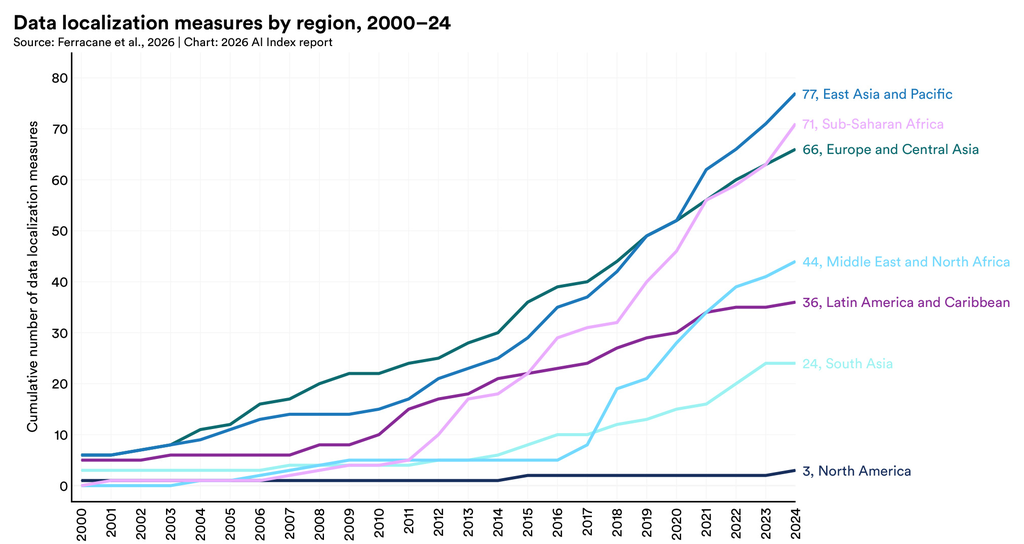

Data localization measures, cumulative to 2024: East Asia & Pacific 77 · sub-Saharan Africa 71 · Europe & Central Asia 66 · North America 3

- Local storage ≠ local law: “extraterritorial reach of a cloud provider’s home-country laws”

Counts measures, not strictness · regional totals hide country variation

Stanford HAI, AI Index 2026, ch. 8 (data: Ferracane); World Bank, WDR 2026, ch. 6

## Test 2, models: whose weights are under the national model?

Fine-tune an open model -> national model, foreign base

- One Singapore program, SEA-LION: bases from Alibaba (China), Google and NVIDIA (US), Swiss AI (Switzerland)

| National model | ← Base model | Base origin |
| --- | --- | --- |
| Qwen-SEA-LION-v4.5-27B-IT (AI Singapore) | Qwen3.6-27B | China (Alibaba) |
| Gemma-SEA-LION-v4-4B-VL (AI Singapore) | Gemma 3 4B | US (Google) |
| Nemotron-SEA-LION-v4.8-120B (AI Singapore) | Nemotron 3 Super 120B | US (NVIDIA) |
| Apertus-SEA-LION-v4-8B-IT (AI Singapore) | Apertus 8B | Switzerland |
| Sarvam-M (India) | Mistral Small 3.1 | France |
| Sahabat-AI Gemma2 9B (Indonesia) | Gemma 2 | US (Google) |

Base models as listed on Hugging Face model cards, 2024–26

Hugging Face model cards

## Test 3, jurisdiction: can a state make a platform comply?

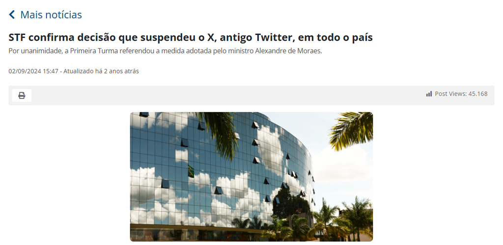

Brazil v. X, 2024

- Aug 30: Justice Moraes suspends X nationwide; Sep 2: panel upholds, unanimous
- Oct 8: X back after compliance + R$28.6M in fines
- “O Brasil é soberano.” Communications Minister

A platform case, not an AI one

STF, Sep 2, 2024; CNN Brasil and TELETIME, Oct 8, 2024

## Does the model speak your language?

“African languages trail English by 30 percentage points … on average”

- 16 African languages, 5 subjects (AfriMMLU)

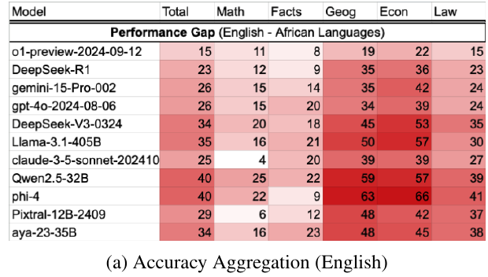

Models from 2024–early 2025 · reasoning models narrow the gap

Lundin et al., “The Token Tax,” AfricaNLP 2026

## Test 4, performance: who builds AI for their own languages?

State platformIndia · Bhashini36+ languages350+ models

GrassrootsAfrica · Masakhane30+ languagesMT benchmarks

Bhashini figures self-reported · Masakhane benchmarks date from 2020

PIB, Feb 10, 2026; Nekoto et al., Findings of EMNLP 2020

## What is Côte d’Ivoire buying?

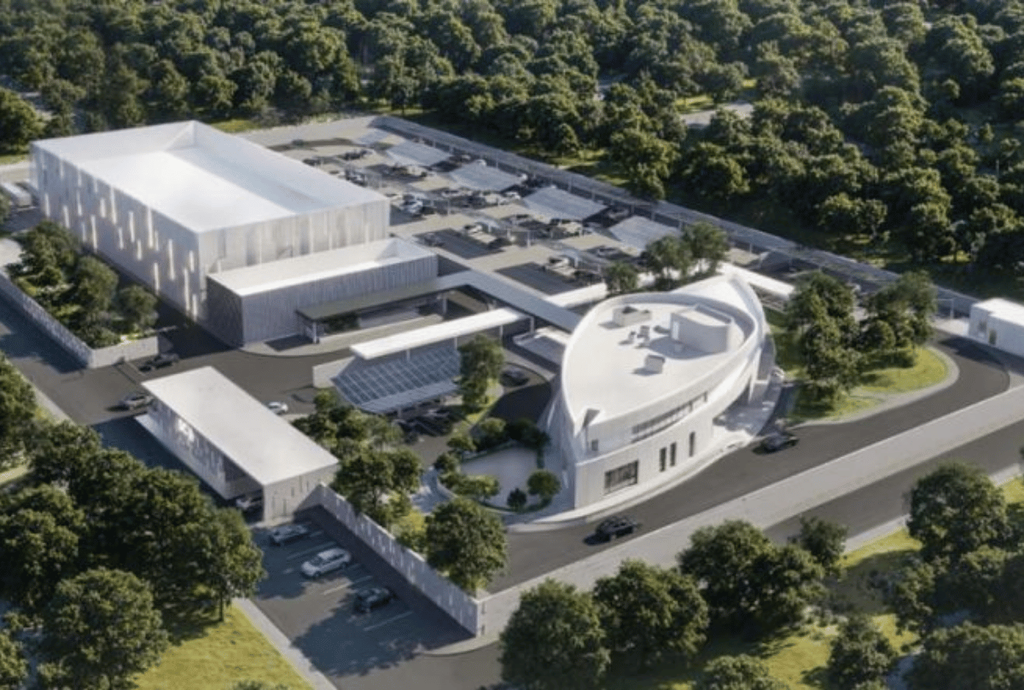

Rendering via TechAfrica News (Aug 4, 2026); attributed to Cybastion

$170M package

$66.1M data center

$170M package, US EXIM-financed: national data center + government digitization platform + border surveillance system

- $66.1M EXIM guarantee for the data center (Aug 2025): “displaces competition from the PRC”
- 1.73 MW IT · launch targeted 2027

How the $170M splits is not public

TechAfrica News, Jul 17, 2026; US EXIM, Aug 21, 2025; DCD, Sep 9, 2026

## Can you buy sovereignty with capital?

[figure not shown]

UAE · Stargate UAE: 1 GW planned, 200 MW first phase announced for 2026

- OpenAI, G42, Oracle, NVIDIA, Cisco, SoftBank · “in coordination with the U.S. government”
- Licence-free US chips for approved firms since Jul 10, 2026

Saudi Arabia · HUMAIN (Public Investment Fund) + NVIDIA chips · Mistral for Arabic models

Announcements, not delivered capacity · 200 MW live status unconfirmed, Nov 16

OpenAI, May 22, 2025; Reuters via Al-Monitor, Jul 2026; NVIDIA, May 13, 2025; Mistral, Aug 24, 2026

## Can the state build it instead?

[figure not shown]

IndiaAI Mission (Mar 2024): ₹10,371.92 crore over five years

- 38,000 GPUs onboarded (privately owned, subsidised) at ₹65/hour
- 12 startups selected to build foundation models
- Output: Sarvam 30B/105B, trained from scratch on IndiaAI compute

Government self-report · onboarded ≠ state-owned

PIB backgrounder, Feb 10, 2026; Sarvam AI, Mar 6, 2026

## Can countries pool their way to sovereignty?

[figure not shown]

EuroHPC: 19 AI Factories + 13 Antennas, shared across member states

- Up to 7 AI Gigafactories: call open, >€20B private investment expected

National champion: Mistral (France), open weights

Gigafactories chosen in early 2027 · call deadlines Dec 3, 2026 (Lot 2), Feb 4, 2027 (Lot 1)

EuroHPC JU, Jul 30, Sep 1 and Nov 5, 2026; Mistral, 2026

## Host others’ compute, or build your own models?

Malaysia hosts

Johor: “$35 billion beneficiary” of Singapore’s 2019–22 moratorium

Peninsular data centers need 8,391 MW by 2030 · Johor 4,428 MW

Permit rule on US AI chip exports and transits (Jul 2025)

Singapore builds

SEA-LION: open, state-funded model · S$70M initiative

Burmese

Indonesian

Filipino

Malay

Tamil

Thai

Vietnamese

Two neighbours, two strategies · Malaysia’s own models not covered here

Reuters via Khaleej Times, Jul 26, 2026; PETRA via The Vibes, Oct 20, 2026; MITI, Jul 14, 2025; IMDA, Dec 4, 2023; AI Singapore model cards

## What does each deal buy?

| Case | Compute | Models | Jurisdiction | Performance |
| --- | --- | --- | --- | --- |
| Côte d’Ivoire | ● |  |  |  |
| Gulf (UAE, Saudi Arabia) | ● | ● |  | ● |
| India | ● | ● |  | ● |
| Europe | ● | ● |  |  |
| Brazil (X case) |  |  | ● |  |
| Southeast Asia | ● | ● |  | ● |

Each buys some tests. None buys all.

● = test the flagship move targets, not how well it does

Slides 21–28

## Is sovereignty worth the price?

“pursuing ‘AI sovereignty’ comes at a high cost and with uncertain benefits”

- “for most countries, the middle path between sovereignty and dependence is a more viable strategy”

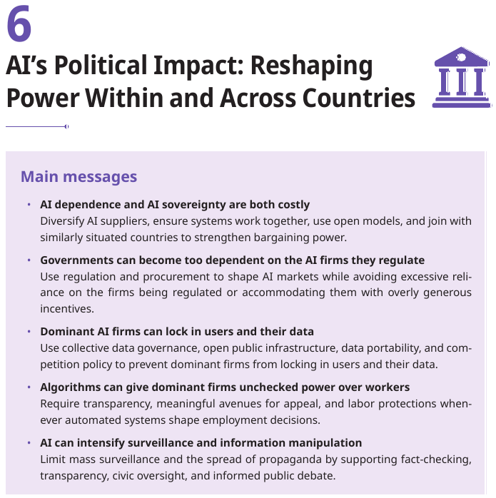

World Bank, WDR 2026 web page (ch. 6 summary) and ch. 6

## Whose stack is under the “sovereign” label?

[figure not shown]

“Narratives around AI sovereignty are often driven by foreign technological companies”

- Côte d’Ivoire’s data center: US export credit, pitched against China
- Mistral: rounds led by ASML (Netherlands), Samsung (Korea)
- HUMAIN: 50 MW reserved for a US client

World Bank, WDR 2026, ch. 6, fn. 17; US EXIM, Aug 2025; Mistral, Sep 2025 and Sep 2026; The National/Reuters, Oct 22, 2026

## Sovereignty audit: where is your country weakest?

Assigned country cards:

India

UAE

France

Côte d’Ivoire

Brazil

Indonesia

1. Alone · 1 min: read your card
2. Groups of 3–4 · 6 min: one auditor per test -> strong / partial / weak; mark the stack layers it owns
3. Report · 5 min: weakest test + one fix you’d fund

Compute

Models

Jurisdiction

Performance

You audit the country; nobody speaks for it · written answers welcome

## Same tests, different weak spots?

| Country | Compute | Models | Jurisdiction | Performance | Fix to fund |
| --- | --- | --- | --- | --- | --- |
| India |  |  |  |  |  |
| UAE |  |  |  |  |  |
| France |  |  |  |  |  |
| Côte d’Ivoire |  |  |  |  |  |
| Brazil |  |  |  |  |  |
| Indonesia |  |  |  |  |  |

# Part III: Who writes the AI rules for everyone else?

Rules travel too: by copying, competing and pressure.

## Who is writing national AI strategies?

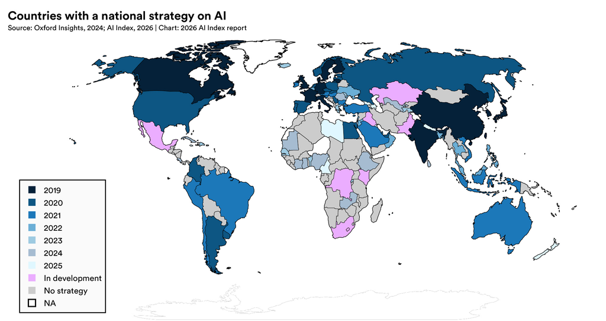

2024: more than half of newly adopted strategies came from emerging economies

Strategy = policy intent, not implementation · the map shows year of adoption, not income group

Stanford HAI, AI Index 2026, ch. 8 (Oxford Insights data)

## Why would a country copy another’s rules?

Coercion*powerful states or organizations change weaker states’ incentives to adopt*

Competition*states adopt what rivals adopted, to keep investment and markets*

Learning*governments update beliefs by watching policy results elsewhere*

Emulation*states copy what looks appropriate, not what is proven to work*

Which one is at work on the next slides?

Simmons, Dobbin & Garrett (2006), *International Organization*

## How does Brussels regulate the world?

De facto: firms “standardize their production globally and adhere to a single rule”

De jure: firms then “lobby their domestic governments to adopt these same standards”

- Needs market power + regulatory capacity

Bradford, *Northwestern University Law Review*, 2012

## Has the EU AI Act travelled?

| Travelling | Partial | Limited |
| --- | --- | --- |
| Brazil PL 2338/2023: “excessive” and “high” risk tiers · passed Senate Dec 2024 · not law | South Korea AI Basic Act, in force Jan 22, 2026: “distinct from the more prescriptive EU model” | “a limited Brussels Effect” (Engler 2022) |
| Prediction: de facto + de jure effects “likely for parts” (Siegmann & Anderljung 2022) |  | Effect likely, but a “side effect” undercuts EU values (Almada & Radu 2024) |

Studies mostly 2022–24 predictions · EU delayed its own high-risk rules to Dec 2027 / Aug 2028

Senate and Chamber of Brazil; US ITA, May 29, 2026; Brookings, Jun 2022; GovAI, Aug 2022; *German Law Journal*, 2024; Regulation (EU) 2026/1744

## What is Washington exporting?

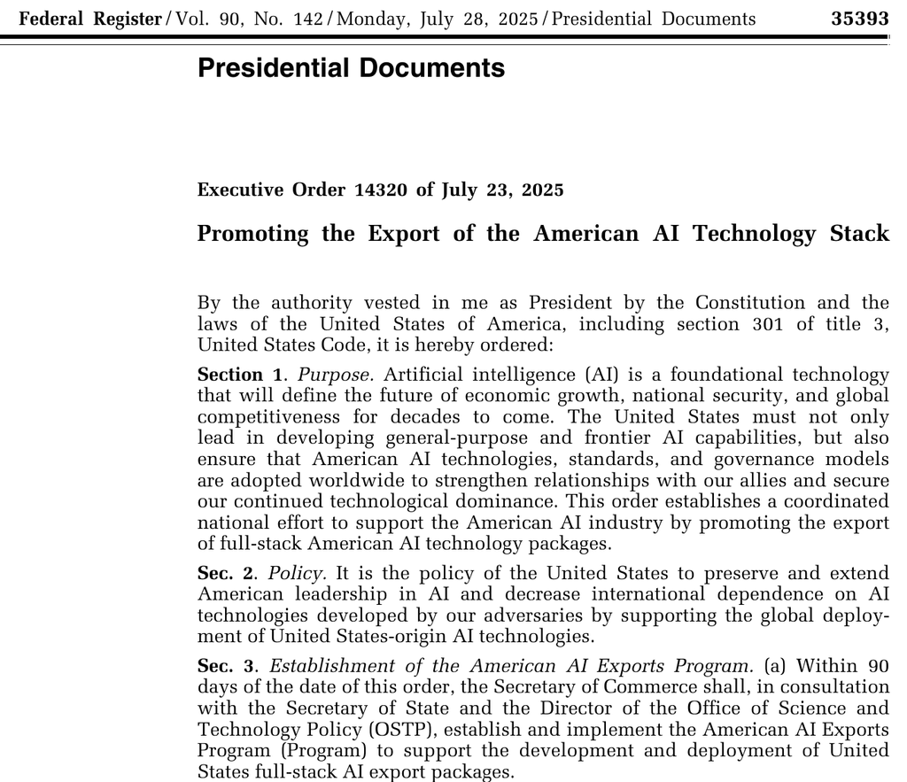

EO 14320 (Jul 23, 2025): export “full-stack American AI technology packages”

- Hardware + cloud · data pipelines · models · security · applications, with federal financing
- “a trusted, sovereign AI stack” (Kratsios, Apr 2026)

Program renamed “SI Exports” (EO 14434, Sep 2026) · 78 applications, no designations found as of Nov 16

Federal Register, Jul 28, 2025; ITA, Apr 1 and Jul 6, 2026; EO 14434

## What is Beijing exporting?

China promotes WAICO “to help countries of the Global South keep pace with the global intelligent transformation, bolster capacity building and avert a new AI divide” Wang Yi, Jul 17, 2026 (MFA readout)

Action Plan (Jul 2025): “assist the Global South in truly accessing and utilizing AI”

WAICO, founded Jul 16, 2026: 29 signatories, 35 by Jul 31 · HQ Shanghai

Open models: Chinese models = 41% of Hugging Face downloads (Feb 2025–Feb 2026)

WAICO founding list only partly published · “Global South” is Beijing’s term

MFA PRC, Jul 2025 and Jul 17, 2026; Xinhua, Jul 17, 2026; TPRA Sudan, Jul 31, 2026; Hugging Face, Mar 17, 2026

## Can everyone else write rules together?

[figure not shown]

[figure not shown]

Jul 2024

African Union Continental AI Strategy, endorsed by Executive Council

Aug 26, 2025

UN resolution A/RES/79/325, adopted by consensus -> Scientific Panel (40 members) + Global Dialogue

Sep 25, 2025

Global Dialogue on AI Governance launched (UNGA80, New York)

Jul 1, 2026

Panel’s first report

Jul 6–7, 2026

first Global Dialogue, Geneva

African Union, Jul 2024; UN General Assembly, Aug 2025; UN Global Dialogue site; UN Geneva, Jul 2026

## Can governments use and oversee AI?

Rules on paper ≠ capacity to use or enforce them

Left: where we found documented government use · Right: a readiness index’s public-sector adoption score

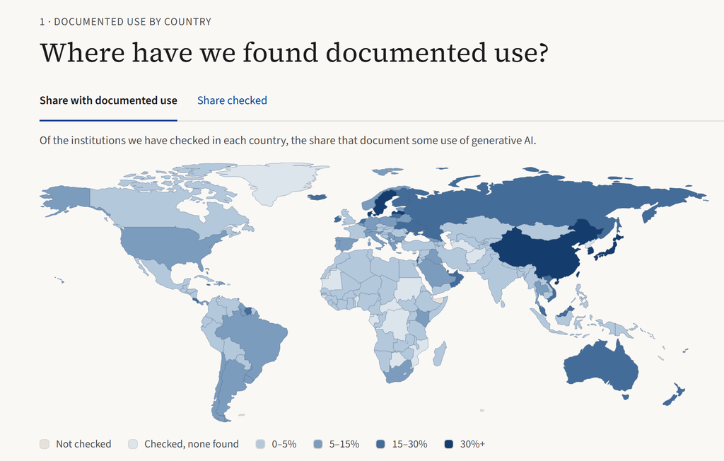

[figure not shown]

G3O = instructor’s own project; English-language search; not documented ≠ not used · pillar = index score, not measured use

Oxford Insights, Government AI Readiness Index 2025 (Dec 2025); G3O, as of Nov 4, 2026

## Who can audit, enforce, or even count?

44 laws

37 authorities

Of 54 African countries: 44 have a data protection law, 37 an operational authority (CIPIT, Apr 2026).

Kenya’s regulator, FY2024/25

**2,071**complaints

**53**enforcement notices

**7**penalty notices

- Named risks: AI “may lack legal framework”; staff retention

Counts differ across trackers (44–45 laws; 37–39 authorities)

CIPIT, Strathmore University, Apr 2026; Auditor-General of Kenya, ODPC report FY2024/25

## What should you take from today?

1. AI = global distributive shock · most countries buy chips, compute and frontier models
2. Four tests: compute, models, jurisdiction, performance · each deal buys some, none buys all, at high cost
3. Rules travel by coercion, competition, learning, emulation · Brussels effect + US and Chinese stack exports · state capacity sets the limit

Vote again: widen or narrow?

Widen

Narrow

No change

Not sure

## See you next class

Peer Review 2 · Sun, Nov 22, 11:59 p.m. · 150–200 words

Wednesday, Nov 18: AI Agents: Reliability, Safety, and Governance · Yiqing Xu

Final presentations · Mon, Nov 30 / Wed, Dec 2 · 5 minutes, 3 slides

Peer Review 3 · in session, Nov 30 / Dec 2